# Mutate Learning Checks

Albert Y. Kim

Wed Oct 14, 2016

## Load Packages and Data

```r
# Load necessary packages
library(ggplot2)
library(dplyr)
library(nycflights13)

# Load flights data set in nycflights
data(flights)
```

## LC

What do positive values of the `gain` variable in `flights_plus` correspond to? What about negative values? And what about a zero value?

```r
flights_plus <- flights %>%
  mutate(gain = arr_delay - dep_delay)
```

### Solution

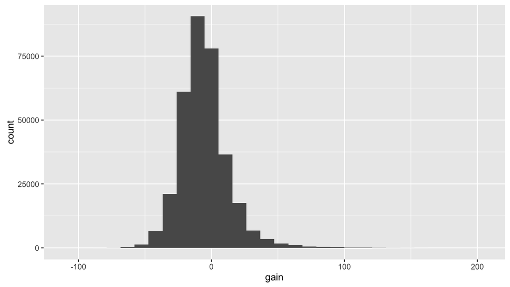

```r
ggplot(data=flights_plus, aes(x=gain)) +
  geom_histogram()
```

- Say a flight departed 20 minutes late, i.e. `dep_delay=20`
- Then arrived 10 minutes late, i.e. `arr_delay=10`.
- Then `gain = arr_delay - dep_delay = 10 - 20 = -10` is negative, so it “made up time in the air”.

0 means the departure and arrival time were the same, so no time was made up in the air. We see in most cases that the `gain` is near 0 minutes.

I never understood this. If the pilot says “we’re going make up time in the air” because of delay by flying faster, why don’t you always just fly faster to begin with?

## LC

Could we create the `dep_delay` and `arr_delay` columns by simply subtracting `dep_time` from `sched_dep_time` and similarly for arrivals? Try the code out and explain any differences between the result and what actually appears in `flights`.

### Solution

Let’s focus on delays first, but let’s assign our newly computed departure delay variable to `dep_delay_new` so as to not overwrite the original `dep_delay` variable. Furthermore, let’s only select the relevant columns to make `View()`ing easier:

```r
new_flights_plus <- flights %>%
  mutate(dep_delay_new = sched_dep_time - dep_time) %>%
  select(sched_dep_time, dep_time, dep_delay, dep_delay_new)
```

Let’s take a look at the first 5 rows:

| sched_dep_time | dep_time | dep_delay | dep_delay_new |
| --- | --- | --- | --- |
| 515 | 517 | 2 | -2 |
| 529 | 533 | 4 | -4 |
| 540 | 542 | 2 | -2 |
| 545 | 544 | -1 | 1 |
| 600 | 554 | -6 | 46 |

Observations:

1. Looking at the first 4 rows we see that when computing delays, you need to substract `sched_dep_time` from `dep_time`, and not vice versa like was asked. A typo to be fixed before Chester and I officially release this textbook later this year after testing!
2. But why are the values in the 5th row different? Because hours don’t have 100 minutes, but 60 minutes!

**Moral of the story**: Always look your data before and after you do anything!